# Tvyal Newsletter

Aghasi Tavadyan

2023-11-13

*English summary below.*

Հարգելի գործընկեր,

Հուսով եմ լավ եք: Ներկայացնում եմ անցած շաբաթվա վերլուծությունները և աշխատանքները.

1. ՀՀ առևտրաշրջանառության վերլուծություն
2. ՀՆԱ-ի հարաբերությունը Հարավային Կովկասի տնտեսություններում
3. English summary

## 1. ՀՀ առևտրաշրջանառության վերլուծություն

Այս շաբաթվա նյուզլեթերի նպատակն է լուսաբանել Հայաստանի առևտրաշրջանառության ուղղությունները։ Այս նյութի նպատակն է լուսաբանել, թե որտեղ և ինչ ենք արտահանում և ինչ պետենցիալ ունի մար պատրաստի, բարձր ավելացված արժեք ունեցող արտադրանքը արտասահմանում։

Այս, ինչպես նաև մեր կողմից հրապարակվող այլ նյութերի վիճակագրական տվյալները և կոդը հասանելի են, նայիր գիթաբի հղումը ներքևում։

### 1.1. Հայաստանի առևտուրը Ռուսաստանի հետ մի քանի խոսքով

2021 թվականին տարեկան արտահանումը կազմում էր 841 մլն դոլար, իսկ ներմուծումը մոտ 2 անգամ ավել էր՝ 1,79 մլրդ դոլար։ Այս պահին հարաբերությունը հակառակն է։ վերջին 2 տարվա ընթացքում արտահանումը աճեց ավելի քան 4 անգամ։

Մեր գնահատականով վերաարտահանումը արտահանման մեջ կազմել է 43 տոկոս։ Ինչպես երևում է գծապատկերից 2023 թվականի կեսերին արտահանումը հասել է իր գագաթնային կետին և այս պահին արտահանման ցուցանիշները դեպի Ռուսաստան ամենայն հավանականությամբ անկման տենդենց ունեն։ (Վերաարտահանման մասին ավելի մանրամասն՝ [Tvyal Newsletter - 2023-09-11](https://www.tvyal.com/newsletter/week-32))։

**Գծապատկեր 1.** Հայաստանի արևտրաշրջանառությունը Ռուսատանի հետ և կանխատեսումը

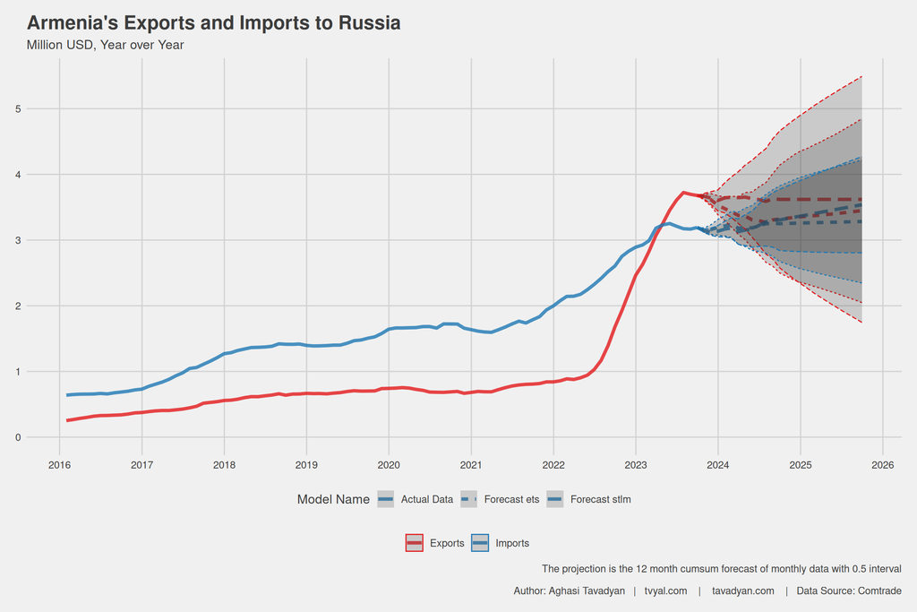

### 1.2. Որո՞նք են Հայաստանի հիմնական առևտրային գործընկերները և ուր է գնում պատրաստի արտադրանքը։

Գծապատկեր 2-ում ցույց տված ցուցանիշներ մեջ դեպի ԵԱՏՄ 84 արտաքին տնտեսական գործունեության հոդվածից վերև գրեթե բոլոր ապրանքները վերաարտահանում են, ինչպես նաև դեպի Միջին Արևելք 71-րդ հոդվածը (թանկարժեք քարեր և մետաղներ) նույնպես վերաարտահանում է։

Դեպի ԵԱՏՄ այս պահին գնում է ընդհանուր արտահանման 55.6 տոկոսը, մոտ 3.8 մլրդ դոլար, դեպի Միջին արևելք արտահանման մոտ 18․8 տոկոսը, 1․3 մլրդ դոլար։ Այսինքն Դեպի ԵԱՏՄ արտահանվում է ապրանքի կեսից ավելին։

Դեպի Չինաստան առյուծի բաժինը պղնձի հանքաքարն է (25-րդ հոդված), այս ուղությունը կազմում է արտահանման 6.1 տոկոսը։

Դեպի Եվրամիություն արտահանման հիմնականում հանքաքարն է և մետաղները (76 տոկոս), բացառություն է կազմում 2013-ից զարգացում ապրած թեթև արդյունաբերությունը, որը այս պահին դեպի ԵՄ արտահանման 18 տոկոսն է։ ԵՄ-ն կազմում է ընդհանուր արտահանման 10.7 տոկոսը 0.73 մլրդ դոլարով։

Դեպի ԵԱՏՄ, հիմնականում Ռուսատան, արտահանումը ունի ամենադիվերսիֆիկացված տեսքը, արտահանվում է բերձր ավելացված արժեք ունեցող վերջնական արտադրանք։ Իհարկե պետք է հանենք վերաարտահանումը, որը այս պահին այդ ուղղությամբ արտահանման կեսից ավելին է (տես 84 բարձր հոդվածները։ Սակայն նույնիսկ եթե հանենք այդ հոդվածները գծապատկերից (մուգ կապույտ և մուգ կարմիր), ապա աճը այստեղ նույնպես զգալի է, գրեթե 2 անգամ։

Պետք է նշել որ վերաարտահանման մեջ Հայաստանի տնտեսության համար կարևոր հոդված է մեքենաների արտահանումը, որը նույնպես որոշակի խթան հանդիսացավ տնտեսության զարգացման համար։

**Գծապատկեր 2.** Հայաստանի արտահանման կառուցվածքը ըստ գործընկեր տարածաշրջանների և ապրանքնատեսակների (2010-2023)

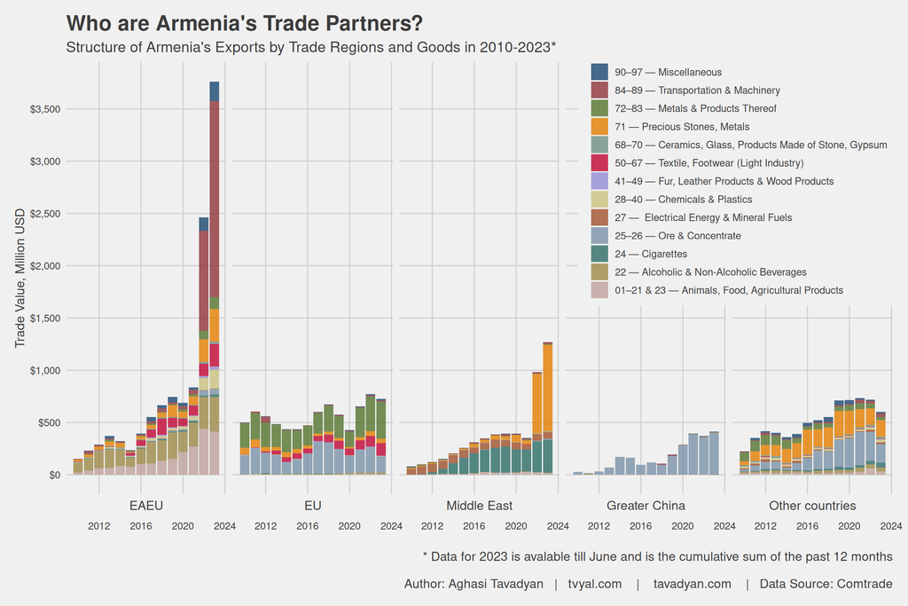

## 2. ՀՆԱ-ի հարաբերությունը Հարավային Կովկասի տնտեսություններում

Ներկա քաղաքա-տնտեսակական զարգացումների համատեքսում կարիք կա նաև ուսումնասիրել Հարավային Կովկասի 3 պետությունների ՀՆԱ-ի դինամիկան, որը թույլ է տալիս ավելի հստակ պատկերացում կազմել պատմական իրողությունների վերաբերյալ։

Գծապատկեր 3-ում զետեղված ամենակարևոր ցուցանիշը գնողունակության համարժեքությամբ հաշվարկված ՀՆԱ-ն է (GDP PPP), որը ցույց է տալիս թե որքան համարժեք ապրանք (նաև զենք, զինամթերք) իր փողով կարող է պետությունը գնել։ 2022 թվականին GDP PPP Հայաստանի համար կազմել է 52.7, Վրաստանի՝ 74.7, իսկ Ադրբեջանի համար 180.8 մլրդ դոլար։

Մինչ 2004 թիվը Հարավային Կովկասի պետությունների ՀՆԱ-ի ցուցանիշները համարժեք էին։ Մեկ շնչի հաշվով Հարավային Կովկասի պետությունները համարժեք են։ Գնողունակության համարժեքությամբ հաշվարկված մեկ շնչով ՀՆԱ-ի ցուցանիշը (GDP per capita, PPP) ցույց է տալիս թե տվյալ պետությունում միջին անհատի հարստության մակարդակը։

**Գծապատկեր 3.** ՀՆԱ-ի համեմատությունը Հարավային Կովկասի պետություններում

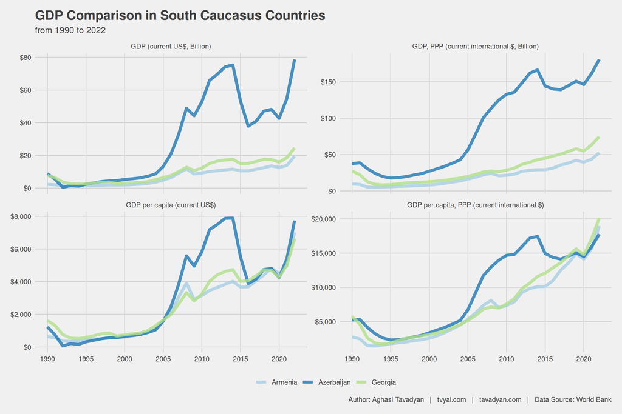

## 3. English Summary

In addition to trade insights, the newsletter provides a glimpse into the GDP relationships among South Caucasus economies. Figure 3 emphasizes the GDP calculated by purchasing power parity (PPP), showcasing the disparity between Armenia, Georgia, and Azerbaijan. While their GDPs were equivalent before 2004, the current figures reveal significant differences, with Azerbaijan leading in GDP PPP. The analysis extends to per capita GDP, indicating the wealth levels of individuals in each country. Understanding these economic dynamics is crucial amidst current political and economic developments in the region, providing a comprehensive view of historical realities and potential future trends.

Այս վերլուծությունը առկա է նաև [մեր կայքեջում](https://www.tvyal.com/newsletter/2023_11_13), այս վերլուծության կոդը և տվյալները դրված է նաև [Github-ում](https://github.com/tavad/tvyal_newsletter)։

Եթե հնարավոր է, խնդրում եմ այս նյութը ուղարկել նաև այն մարդկանց, ում այն կարծում եք կարող է հետաքրքրել:

Սպասեք հաջորդ հաղորդագրությանը մի շաբաթվա ընթացքում:

Հարգանքներով,  
Աղասի Թավադյան  
13.11.2023  
[tvyal.com](https://www.tvyal.com/)  
[tavadyan.com](https://www.tavadyan.com/)

**Ուշադրություն. Ձեր էլ.փոստը մեյլիսթի մեջ է, որի միջոցով ես կիսվում եմ շաբաթական նյութեր, որոնք հիմնականում ներկայացնում են Հայաստանի տնտեսությանը: Նյութերը ներառում են գծապատկերներ, [տվյալների բազաներ](https://github.com/tavad/tvyal_newsletter), տեսանյութեր, հոդվածներ, [առցանց վահանակներ](https://www.tvyal.com/projects), տնտեսական գործիքներ, կանխատեսումներ և հաշվետվություններ: Եթե ցանկանում եք չեղարկել բաժանորդագրությունը, խնդրում եմ տեղեկացրեք ինձ, և ես կհեռացնեմ ձեր էլ. փոստը ցուցակից: Գրեք նաև եթե ունեք մենկնաբանություններ:**

**Important! Your email is part of the mailing list where I share weekly materials primarily focused on the Armenian economy. These materials encompass charts, [databases](https://github.com/tavad/tvyal_newsletter), videos, articles, [online dashboards](https://www.tvyal.com/projects), economic tools, forecasts, and reports. If you wish to unsubscribe, please let me know, and I will remove your email from the list. Please share your comments as well․**